# Exploratory Data Analysis

# Orator 1: William Hayward

### Q1: How does energy consumption by source change by season? Is this effect, or lack thereof, consistent across all types of sources and years?

First, I created a season column. Since our data was organized by month, I generalized the seasons into 3 months each: Winter - December, January, February Spring - March, April, May Summer - June, July, August Autumn - September, October, November

```r
# create column for season
Energy$Season = NA
# assign each month to a season using for loop
for (i in 1:nrow(Energy)) {
  if (Energy$Month[i] == "January" | Energy$Month[i] == "December" | Energy$Month[i] == "February") {
    Energy$Season[i] = "Winter"
  }
  if (Energy$Month[i] == "March" | Energy$Month[i] == "April" | Energy$Month[i] == "May") {
    Energy$Season[i] = "Spring"
  }
  if (Energy$Month[i] == "June" | Energy$Month[i] == "July" | Energy$Month[i] == "August") {
    Energy$Season[i] = "Summer"
  }
  if (Energy$Month[i] == "September" | Energy$Month[i] == "October" | Energy$Month[i] == "November") {
    Energy$Season[i] = "Autumn"
  }
}
# clean up memory
rm(i)
```

Next, I filtered the data so it only included dates and information about consumption by source. Then, I grouped it by season to answer the first part of my question.

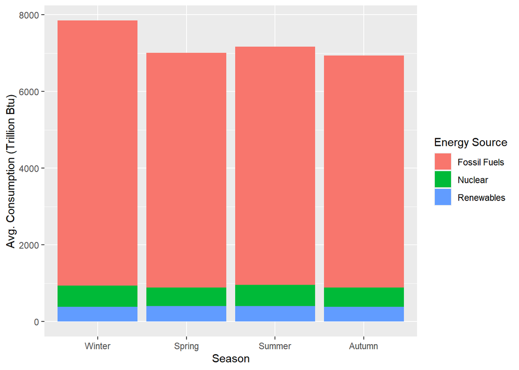

```r
ordered_seasons = c("Winter", "Spring", "Summer", "Autumn")
# call function
Energy %>%
    select(Year, Season, contains("Consumption"), -contains("Primary")) %>%
    group_by(Season) %>%
    summarize(
      avgFossilFuel = mean(`Total Fossil Fuels Consumption`),
      avgNuclear = mean(`Nuclear Electric Power Consumption`),
      avgRenewable = mean(`Total Renewable Energy Consumption`)
    ) %>%
  # gather data to create stacked barplot
  gather(energySource, value, 2:4) %>%
  ggplot(mapping = aes(x = factor(Season, ordered_seasons), y = value, fill = energySource)) +
    geom_bar(stat = "identity") +
    labs(x = "Season", y = "Avg. Consumption (Trillion Btu)") +
    scale_fill_discrete(name = "Energy Source", labels = c("Fossil Fuels", "Nuclear", "Renewables"))
```

```r
# clean up memory
rm(ordered_seasons)
```

As shown by the plot above, energy usage is highest in the winter. Although no definite conclusions can be made, this is likely because natural gas usage is higher from heating buildings.

For the second part of my question, I grouped the data by season and year to make a line chart with year on the x-axis.

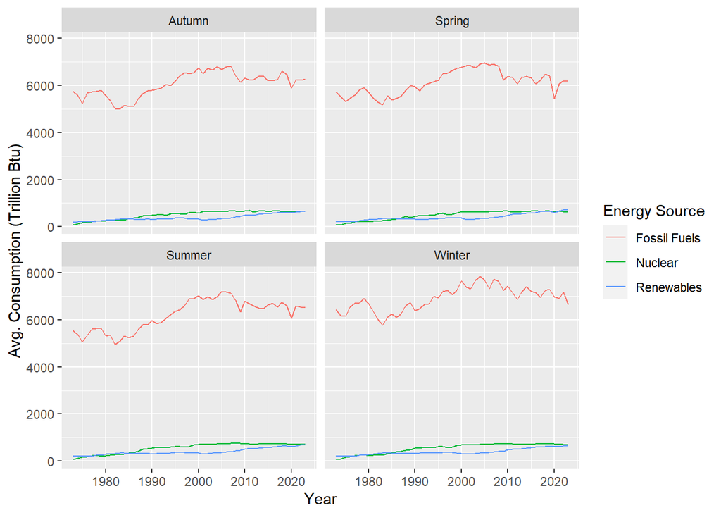

```r
Energy$Year = as.numeric(Energy$Year)
Energy %>%
  select(Year, Season, contains("Consumption"), -contains("Primary")) %>%
  group_by(Season, Year) %>%
  summarize(
    avgFossilFuel = mean(`Total Fossil Fuels Consumption`),
    avgNuclear = mean(`Nuclear Electric Power Consumption`),
    avgRenewable = mean(`Total Renewable Energy Consumption`)
  ) %>%
  # How does energy consumption by source change by season? Is this effect, or lack thereof, consistent across all types of sources and years?
  ungroup() %>%
  gather(energySource, value, 3:5) %>%
  ggplot(aes(x = Year)) +
    geom_line(aes(y = value, color = energySource)) +
    facet_wrap(vars(Season)) +
    labs(x = "Year", y = "Avg. Consumption (Trillion Btu)") +
    scale_color_discrete(name = "Energy Source", labels = c("Fossil Fuels", "Nuclear", "Renewables"))
```

Based on the above graphs, this trend is only consistent for fossil fuels. Fossil fuel usage in the Winter has historically been higher than usage in the Summer. However, the difference in usage between the seasons has decreased over time. Comparing the most recent values to the values around 1980 show that average fossil fuel usage in the summer has increased over time.

### Q2: Do certain changes in energy consumption hint at a possibility of economic recessions? Is this effect, or lack thereof, consistent across the sectors? How are some sectors more or less affected by the assumed periods of economic recessions?

According to [Investopedia](https://www.investopedia.com/articles/economics/08/past-recessions.asp), there were 6 economic recessions in the US during the time period of available data:

1. The Iran and Volcker Recession, Pt. 1
- January 1980 - July 1980
2. The Iran and Volcker Recession, Pt. 2
- July 1981 - November 1982
3. The Gulf War Recession
- July 1990 - March 1991
4. The Dot-Bomb Recession
- March 2001 - November 2001
5. The Great Recession
- December 2007 - June 2009
6. The COVID-19 Recession
- February 2020 - April 2020

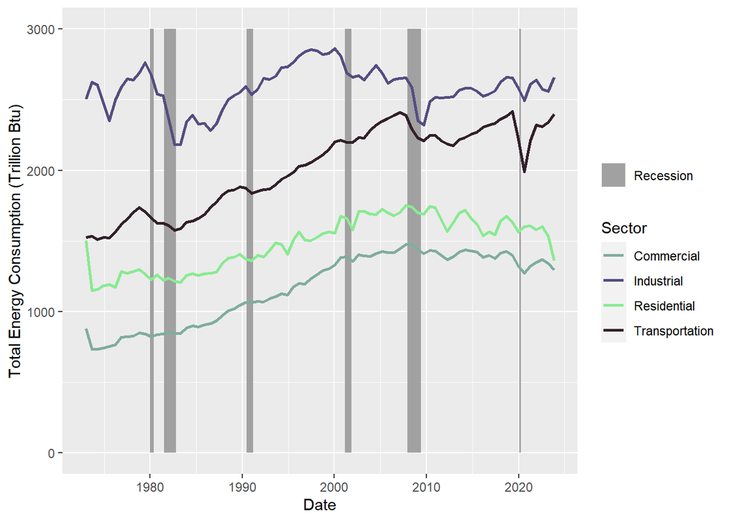

```r
# create date column in energy using the date format. REQUIRED FOR GGPLOT
Energy$Date = paste(Energy$Year, Energy$Month, "01", sep = " ")
Energy$Date = as.Date(Energy$Date, "%Y %B %d")

# used to make legend in plot
colors = c("Industrial" = "#564D80", "Transportation" = "#33202a", "Residential" = "#8aea92", "Commercial" = "#80ada0", "Recession" = "#a1a1a1")

Energy %>%
  select(Date, contains("Total Energy Consumed"), -contains("End-Use-Sectors")) %>%
  ggplot(aes(x = Date)) +
  # iran pt 1
    geom_rect(inherit.aes = FALSE, aes(xmin = as.Date("1980-01-01"), xmax = as.Date("1980-06-01"), ymin = 0, ymax = 3000, fill = "Recession")) +
  # iran pt 2
    geom_rect(inherit.aes = FALSE, aes(xmin = as.Date("1981-07-01"), xmax = as.Date("1982-11-01"), ymin = 0, ymax = 3000, fill = "Recession")) +
  # gulf war
  geom_rect(inherit.aes = FALSE, aes(xmin = as.Date("1990-07-01"), xmax = as.Date("1991-03-01"), ymin = 0, ymax = 3000, fill = "Recession")) +
  # dot bomb
  geom_rect(inherit.aes = FALSE, aes(xmin = as.Date("2001-03-01"), xmax = as.Date("2001-11-01"), ymin = 0, ymax = 3000, fill = "Recession")) +
  # housing crisis
  geom_rect(inherit.aes = FALSE, aes(xmin = as.Date("2007-12-01"), xmax = as.Date("2009-06-01"), ymin = 0, ymax = 3000, fill = "Recession")) +
  # covid
  geom_rect(inherit.aes = FALSE, aes(xmin = as.Date("2020-02-01"), xmax = as.Date("2020-04-01"), ymin = 0, ymax = 3000, fill = "Recession")) +
  # sector consumption. span argument used to remove sharp differences between months.
    geom_smooth(se = F, span = 0.05, aes(y = `Total Energy Consumed by the Residential Sector`, color = "Residential")) +
    geom_smooth(se = F, span = 0.05, aes(y = `Total Energy Consumed by the Commercial Sector`, color = "Commercial")) +
    geom_smooth(se = F, span = 0.05, aes(y = `Total Energy Consumed by the Industrial Sector`, color = "Industrial")) +
    geom_smooth(se = F, span = 0.05, aes(y = `Total Energy Consumed by the Transportation Sector`, color = "Transportation")) +
  scale_color_manual(name = "Sector", values = colors) +
  scale_fill_manual(name = " ", values = colors) +
  labs(y = "Total Energy Consumption (Trillion Btu)", x = "Date")
```

```r
# free up memory
rm(colors)
```

In the above graph, the total energy consumption by month was plotted using a LOESS regression with a smoothing parameter of 0.05. This was done to reduce sharp differences between months that would make the graph difficult to read. Additionally, I added indicators to highlight periods of economic recession.

# Orator 2: Deeya Pathak

### Q1: Which sectors have the largest difference between primary and end-use energy consumption annually? How do they compare with each other? Are there relationships between sectors for these energy differences?

Primary energy consumption, measured in trillions of BTU, refers to the total amount of energy initially harvested from a source, while end-use energy consumption, also measured in trillions of BTU, focuses on the energy that was actually used.

Using the EnergyConsumption dataset, I first created a new variable called `Year` by separating the `Month` variable in order to conduct my analysis. After grouping the data by year, I calculated the average primary energy consumed and average end-use energy consumed for three sectors: Residential, Commercial, and Industrial. These three sectors were selected for consistency purposes, because the original dataset had information on these three sectors. Finally, I calculated the difference between end-use and primary consumption per sector. All of these calculations per year are stored in a tibble called EnergyConsumption3.

```r
EnergyConsumption2 = EnergyConsumption %>%
  separate(Month, into = c("Year", "Month"), sep = " ") %>%
  group_by(Year) %>%
  mutate_at(1, as.numeric)


(EnergyConsumption3 = EnergyConsumption2 %>%
  summarize(prim_res_avg = mean(`Primary Energy Consumed by the Residential Sector`),
            end_res_avg = mean(`End-Use Energy Consumed by the Residential Sector`),
            res_diff = end_res_avg - prim_res_avg,
            prim_comm_avg = mean(`Primary Energy Consumed by the Commercial Sector`),
            end_comm_avg = mean(`End-Use Energy Consumed by the Commercial Sector`),
            comm_diff = end_comm_avg - prim_comm_avg,
            prim_ind_avg = mean(`Primary Energy Consumed by the Industrial Sector`),
            end_ind_avg = mean(`End-Use Energy Consumed by the Industrial Sector`),
            ind_diff = end_ind_avg - prim_ind_avg,
            .groups = 'drop'))
```

```
## # A tibble: 51 × 10
##     Year prim_res_avg end_res_avg res_diff prim_comm_avg end_comm_avg comm_diff
##    <dbl>        <dbl>       <dbl>    <dbl>         <dbl>        <dbl>     <dbl>
##  1  1973         686.        850.     165.          369.         495.      126.
##  2  1974         659.        823.     164.          355.         480.      125.
##  3  1975         666.        833.     167.          338.         471.      133.
##  4  1976         699.        872.     172.          364.         504.      140.
##  5  1977         683.        866.     183.          355.         501.      146.
##  6  1978         688.        880.     192.          359.         510.      151.
##  7  1979         660.        854.     194.          364.         518.      155.
##  8  1980         620.        824.     204.          342.         501.      159.
##  9  1981         587.        792.     205.          320.         489.      169.
## 10  1982         596.        803.     207.          322.         495.      173.
## # ℹ 41 more rows
## # ℹ 3 more variables: prim_ind_avg <dbl>, end_ind_avg <dbl>, ind_diff <dbl>
```

After forming the above tibble, I calculated the average values of the mean differences of each sector. The average annual residential sector difference between end-use and primary energy consumption is 310.74 trillion BTU; the average annual commercial sector difference between end-use and primary energy consumption is 285.04 trillion BTU; and the average annual industrial sector difference between end-use and primary energy consumption is 265.30 trillion BTU.

```r
residential_avg <- mean(EnergyConsumption3$res_diff)
commercial_avg <- mean(EnergyConsumption3$comm_diff)
industrial_avg <- mean(EnergyConsumption3$ind_diff)
```

I created a scatter plot to display the primary and end-use consumption of the specified sectors over time. It was interesting to see that the industrial sector consumption (primary and end-use) was over 500 trillion BTU higher than the other sectors.

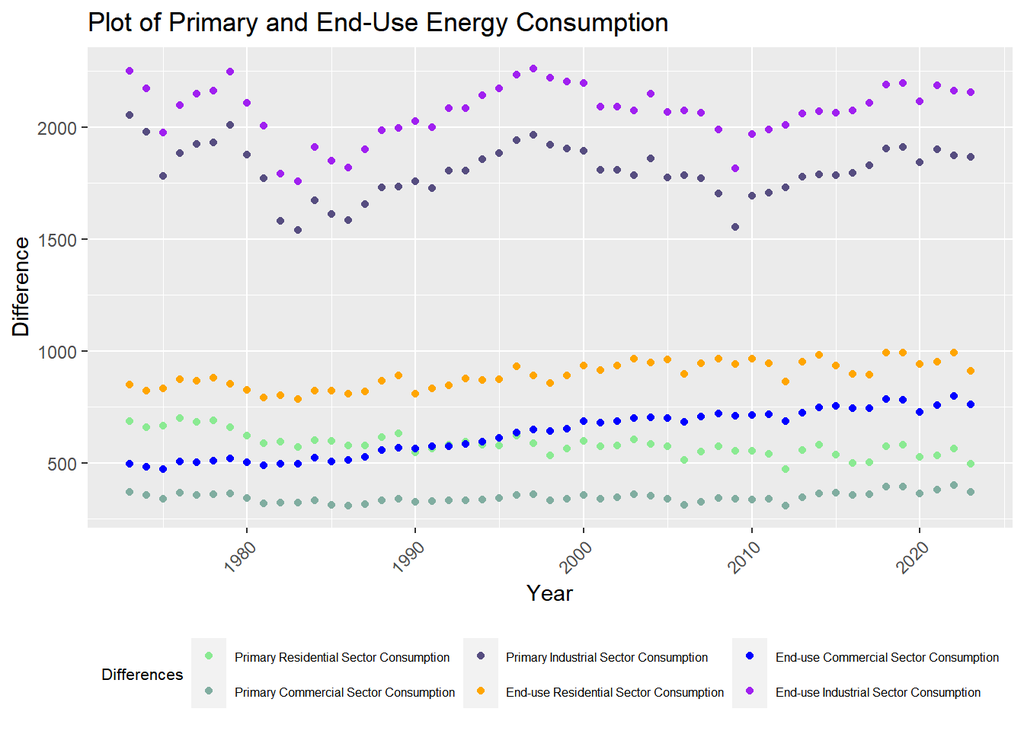

```r
ggplot(EnergyConsumption3, aes(x=Year)) +
  geom_point(aes(y=prim_res_avg, color = "Primary Residential Sector Consumption")) +
  geom_point(aes(y=prim_comm_avg, color = "Primary Commercial Sector Consumption")) +
  geom_point(aes(y=prim_ind_avg, color = "Primary Industrial Sector Consumption")) +
  geom_point(aes(y=end_res_avg, color = "End-use Residential Sector Consumption")) +
  geom_point(aes(y=end_comm_avg, color = "End-use Commercial Sector Consumption")) +
  geom_point(aes(y=end_ind_avg, color = "End-use Industrial Sector Consumption")) +
  labs(title = "Plot of Primary and End-Use Energy Consumption", x = "Year", y = "Difference") +
  theme(axis.text.x = element_text(angle = 45, hjust = 1),
        legend.position = "bottom",
        legend.text = element_text(size = 6),
    legend.title = element_text(size = 8)) +
  scale_color_manual(name = "Differences",
                     breaks = c("Primary Residential Sector Consumption",
                                "Primary Commercial Sector Consumption",
                                "Primary Industrial Sector Consumption",
                                "End-use Residential Sector Consumption",
                                "End-use Commercial Sector Consumption",
                                "End-use Industrial Sector Consumption"),
                     values = c("Primary Residential Sector Consumption" = "#8aea92",
                                "Primary Commercial Sector Consumption" = "#80ada0",
                                "Primary Industrial Sector Consumption" = "#564D80",
                                "End-use Residential Sector Consumption" = "orange",
                                "End-use Commercial Sector Consumption" = "blue",
                                "End-use Industrial Sector Consumption" = "purple"))
```

I created a second plot using the annual differences between average end-use and primary use energy consumption in each sector to view overall trends over time. The graph shows that the Industrial Sector difference in consumption changed the least between 1973 and 2023, while the Commercial Sector difference in consumption changed the most. Smaller differences can be used to determine efficiency, so from this graph, we can conclude that the commercial sector used to be the most efficient in energy consumption until 1997, but since then, the industrial sector has been more efficient.

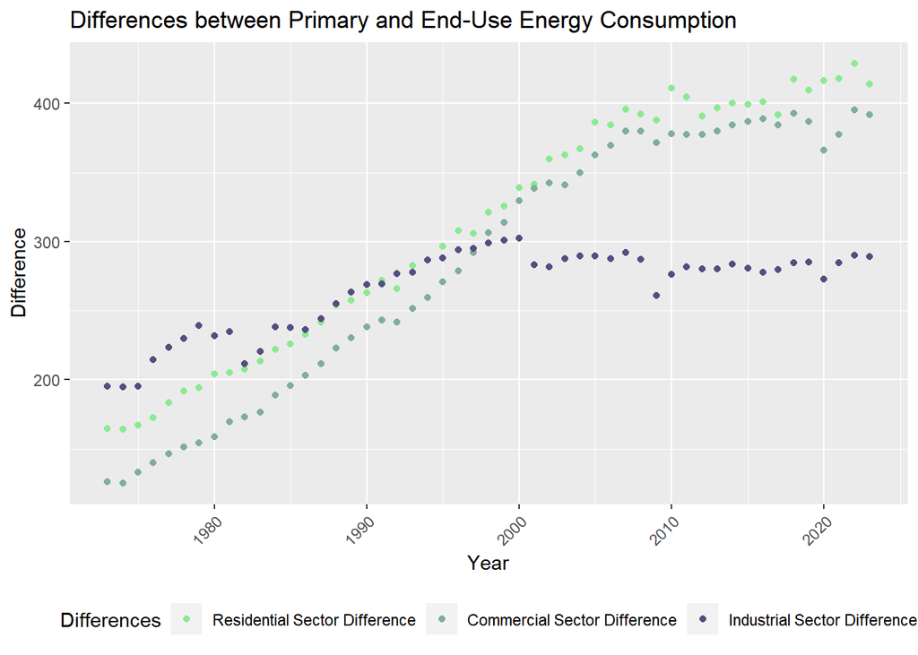

```r
ggplot(EnergyConsumption3, aes(x=Year)) +
  geom_point(aes(y=res_diff, color = "Residential Sector Difference")) +
  geom_point(aes(y=comm_diff, color = "Commercial Sector Difference")) +
  geom_point(aes(y=ind_diff, color = "Industrial Sector Difference")) +
  labs(title = "Differences between Primary and End-Use Energy Consumption", x = "Year", y = "Difference") +
  theme(axis.text.x = element_text(angle = 45, hjust = 1),
        legend.position = "bottom") +
  scale_color_manual(name = "Differences",
                     breaks = c("Residential Sector Difference",
                                "Commercial Sector Difference",
                                "Industrial Sector Difference"),
                     values = c("Residential Sector Difference" = "#8aea92",
                                "Commercial Sector Difference" = "#80ada0",
                                "Industrial Sector Difference" = "#564D80"))
```

### Q2: Is there a relationship between primary energy imports and exports? If so, is it positive, negative, or neutral? How strong is the correlation?

A scatterplot betweeen primary energy imports and exports shows an interesting relationship between the two variables. There appears to be a mostly neutral relationship, except for the discrepancy between import levels between ~1500 and ~2500 trillion BTU and export levels greater than 1000 trillion BTU. I graphed a linear model with a correlation coefficient of 0.12, suggesting a weak but positive relationship.

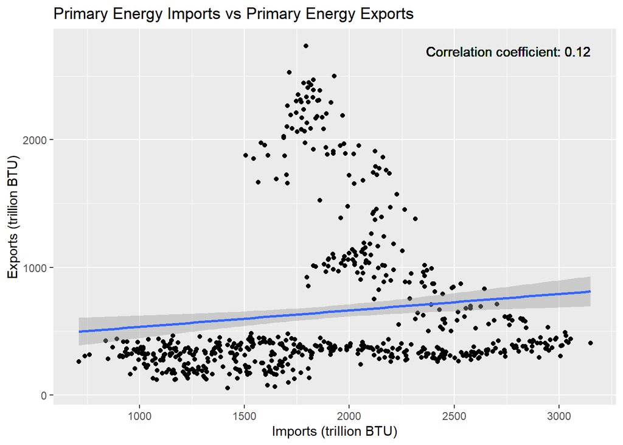

```r
correlation_coefficient <- cor(PrimaryEnergyOverview$`Primary Energy Imports`, PrimaryEnergyOverview$`Primary Energy Exports`)

ggplot(PrimaryEnergyOverview, aes(x=`Primary Energy Imports`, y=`Primary Energy Exports`)) +
  geom_point() +
  geom_smooth(method=lm) +
  geom_text(x = max(PrimaryEnergyOverview$`Primary Energy Imports`),
            y = max(PrimaryEnergyOverview$`Primary Energy Exports`),
            label = paste("Correlation coefficient:",
                          round(correlation_coefficient,
                                digits = 2)),
                                hjust = 1,
                                vjust = 1) +
  labs(title = "Primary Energy Imports vs Primary Energy Exports",
       x = "Imports (trillion BTU)", y = "Exports (trillion BTU)")
```

Since the import/export relationship was intriguing, I wanted to see if Year was a potential covariate. Since the data ranged from 1973 - 2023, I chose to categorize the years into decades to provide an easier visual.

```r
PrimaryEnergyOverview2 = PrimaryEnergyOverview %>%
  separate(Month, into = c("Year", "Month"), sep = " ") %>%
  group_by(Year) %>%
  mutate_at(1, as.numeric)

# create column for season
PrimaryEnergyOverview2$YearGroup = NA
# assign each month to a season using for loop
for (i in 1:nrow(PrimaryEnergyOverview2)) {
  if (PrimaryEnergyOverview2$Year[i] >= 1973 & PrimaryEnergyOverview2$Year[i] <= 1983) {
    PrimaryEnergyOverview2$YearGroup[i] <- "1973 - 1983"
  }
  if (PrimaryEnergyOverview2$Year[i] >= 1984 & PrimaryEnergyOverview2$Year[i] <= 1993) {
    PrimaryEnergyOverview2$YearGroup[i] <- "1984 - 1993"
  }
  if (PrimaryEnergyOverview2$Year[i] >= 1994 & PrimaryEnergyOverview2$Year[i] <= 2003) {
    PrimaryEnergyOverview2$YearGroup[i] <- "1994 - 2003"
  }
  if (PrimaryEnergyOverview2$Year[i] >= 2004 & PrimaryEnergyOverview2$Year[i] <= 2013) {
    PrimaryEnergyOverview2$YearGroup[i] <- "2004 - 2013"
  }
  if (PrimaryEnergyOverview2$Year[i] >= 2014 & PrimaryEnergyOverview2$Year[i] <= 2023) {
    PrimaryEnergyOverview2$YearGroup[i] <- "2014 - 2023"
  }
}
```

Graphing the relationship between imports and exports and adding a color aesthetic to the YearGroup I created showed that the decade that I look at has an impact on this relationship, from 2004 onwards. Between 1973 and 2003, although imports did increase over time, there isn’t much change in the level of exports.

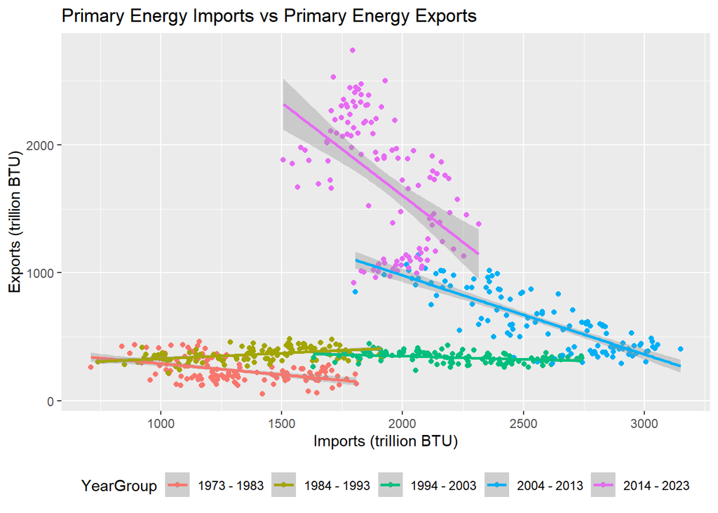

```r
ggplot(PrimaryEnergyOverview2, aes(x=`Primary Energy Imports`, y=`Primary Energy Exports`, color = YearGroup)) +
  geom_point() +
  geom_smooth(method=lm) +
  labs(title = "Primary Energy Imports vs Primary Energy Exports",
       x = "Imports (trillion BTU)", y = "Exports (trillion BTU)") +
  theme(legend.position = "bottom")
```

# Deliverer: Jennifer Kwon

### Q1: Which sector has the highest total energy consumption?

```r
Energy %>%
  select(starts_with("Total") & (ends_with("Sector") | ends_with("Sectors"))) %>% #selection of total energy consumption for each sector and overall energy usage
  select(-c(4,6,7)) %>% #deselect variables that were selected from the code above but aren't relevant (not total energy for a sector or end-use)
  gather(1:4, key = "Sector Type", value = "Sector Measurement") %>% #combine data for sectors to create a variable that has all sector type and corresponding values
  group_by(`Sector Type`) %>% #group by sector to facilitate calculation
  summarize(meanSector = mean(`Sector Measurement`), #average value
            meanTotal = mean(`Total Energy Consumed by the End-Use-Sectors`), #average total
            prop = meanSector / meanTotal) %>% #proportion of sector energy use from the total
  kbl("html") %>% #table design
  kable_material_dark()
```

| Sector Type | meanSector | meanTotal | prop |
| --- | --- | --- | --- |
| Total Energy Consumed by the Commercial Sector | 1171.284 | 7249.154 | 0.1615753 |
| Total Energy Consumed by the Industrial Sector | 2582.882 | 7249.154 | 0.3563012 |
| Total Energy Consumed by the Residential Sector | 1484.044 | 7249.154 | 0.2047196 |
| Total Energy Consumed by the Transportation Sector | 2010.944 | 7249.154 | 0.2774039 |

The industrial sector accounts for the most consumption with 35.63% of the total average energy consumption.

### Q2: What proportions of energy consumption are energy loss across each sector? What changes do the proportions go through over time? Which sector reports the largest change in energy loss? Does this vary by the time of the year?

```r
Energy %>%
  select(contains ("Energy Losses") | (starts_with("Total") & ends_with("Sector"))) %>% #selection of variables with energy loss and total energy consumption
  rename(`Transportation Sector Electrical System Energy Losses` = `Electrical System Energy Losses Proportioned to the Transportation Sector`) %>% #rename transportation variable to align the formatting of the other variables
  select(-8) %>% #deselect irrelevant data variable that was selected from the first line of code
  gather(1:4, key = "Sector Type", value = "Sector Measurement") %>% #combine data for sectors to create a variable that has all sector type and corresponding values
  gather(1:4, key = "Total Sector", value = "Total Measurement") %>% #combine data for sectors to create a variable that has all sector type and corresponding total values
  group_by(`Sector Type`, `Total Sector`) %>% #group by sector to facilitate calculation
  summarize(meanSector = mean(`Sector Measurement`), #average value
            meanTotal = mean(`Total Measurement`),  #average total
            prop = meanSector / meanTotal) %>% #proportion of sector energy loss from the total
  .[-c(2,3,4,5,7,8,9,10,12,13,14,15), ] %>% #deselect proportion calculations where the sector types do not match (ex. energy loss from residential / total energy usage from commercial)
  kbl("html") %>% #table design
  kable_material_dark()
```

| Sector Type | Total Sector | meanSector | meanTotal | prop |
| --- | --- | --- | --- | --- |
| Commercial Sector Electrical System Energy Losses | Total Energy Consumed by the Commercial Sector | 541.346434 | 1171.284 | 0.4621819 |
| Industrial Sector Electrical System Energy Losses | Total Energy Consumed by the Industrial Sector | 512.453535 | 2582.882 | 0.1984038 |
| Residential Sector Electrical System Energy Losses | Total Energy Consumed by the Residential Sector | 591.757357 | 1484.044 | 0.3987465 |
| Transportation Sector Electrical System Energy Losses | Total Energy Consumed by the Transportation Sector | 2.982362 | 2010.944 | 0.0014831 |

# Follow-up Questions

### New Questions Based Off Initial Investigation

- Q1: How did the COVID-19 pandemic affect energy usage by sector, and how much qwew renewable and nonrenewable energy affected by it?
- Q2: How are the high correlations between primary energy imports and exports from 2004 to 2023 correlated to changes in energy consumption in each sector and as a whole?
- Q3: How much energy is wasted annually from energy loss, and to what extent are they sourced by renewable or nonrenewable energy? Around when energy loss is larger than the linear regression, energy consumption by source as a whole increases.
- Q4: Which is a more important factor when considering changes in energy consumption: year or season? In other words, are the changes in energy consumption more notable as the years change, or are there bigger jumps in consumption within a year?

### Investigation of Follow-up Questions

Our group decided to investigate Q1 and Q2 in further detail.

Question 1

```r
EnergyPre =
  select(Energy, Date, contains("Total Energy Consumed"), -contains("End-Use-Sectors")) %>%
  filter(Date >= as.Date("2018-02-01") & Date <= as.Date("2020-01-01"))

avgPreRes = mean(EnergyPre$`Total Energy Consumed by the Residential Sector`)
avgPreCom = mean(EnergyPre$`Total Energy Consumed by the Commercial Sector`)
avgPreInd = mean(EnergyPre$`Total Energy Consumed by the Industrial Sector`)
avgPreTra = mean(EnergyPre$`Total Energy Consumed by the Transportation Sector`)

EnergyPost =
  select(Energy, Date, contains("Total Energy Consumed"), -contains("End-Use-Sectors")) %>%
  filter(Date >= as.Date("2021-02-01"))

avgPostRes = mean(EnergyPost$`Total Energy Consumed by the Residential Sector`)
avgPostCom = mean(EnergyPost$`Total Energy Consumed by the Commercial Sector`)
avgPostInd = mean(EnergyPost$`Total Energy Consumed by the Industrial Sector`)
avgPostTra = mean(EnergyPost$`Total Energy Consumed by the Transportation Sector`)

preVsPost = data.frame(
  Sector = c("Residential", "Commercial", "Industrial", "Transportation"),
  `Pre Pandemic` = c(avgPreRes, avgPreCom, avgPreInd, avgPreTra),
  `Post Pandemic` = c(avgPostRes, avgPostCom, avgPostInd, avgPostTra)
  )

preVsPost %>%
  kbl("html") %>%
  kable_material_dark()
```

| Sector | Pre.Pandemic | Post.Pandemic |
| --- | --- | --- |
| Residential | 1630.164 | 1553.826 |
| Commercial | 1396.720 | 1337.732 |
| Industrial | 2645.890 | 2589.970 |
| Transportation | 2382.417 | 2308.847 |

```r
rm(EnergyPost, EnergyPre, avgPostRes, avgPostCom, avgPostInd, avgPostTra, avgPreInd, avgPreTra, avgPreCom, avgPreRes)


Q1TOT = Q1_year %>%
  filter(between(Year, 2018, 2023)) %>%
  select(-`Primary Energy Consumption by Year`) %>%
  mutate(`Total Energy` = `Fossil Fuels Consumption by Year` + `Renewable Energy Consumption by Year`)

(Q1RE = Q1TOT %>%
  select(-`Fossil Fuels Consumption by Year`) %>%
  mutate(Proportion = `Renewable Energy Consumption by Year` / `Total Energy`) %>%
  kbl("html") %>%
  kable_material_dark())
```

| Year | Renewable Energy Consumption by Year | Total Energy | Proportion |
| --- | --- | --- | --- |
| 2018 | 7534.557 | 88815.10 | 0.0848342 |
| 2019 | 7593.826 | 88018.37 | 0.0862755 |
| 2020 | 7300.518 | 80439.88 | 0.0907574 |
| 2021 | 7644.252 | 85097.86 | 0.0898290 |
| 2022 | 8090.852 | 86589.03 | 0.0934397 |
| 2023 | 7551.327 | 77813.15 | 0.0970444 |

```r
(Q1NON = Q1TOT %>%
  select(-`Renewable Energy Consumption by Year`) %>%
  mutate(Proportion = `Fossil Fuels Consumption by Year` / `Total Energy`) %>%
  kbl("html") %>%
  kable_material_dark())
```

| Year | Fossil Fuels Consumption by Year | Total Energy | Proportion |
| --- | --- | --- | --- |
| 2018 | 81280.54 | 88815.10 | 0.9151658 |
| 2019 | 80424.54 | 88018.37 | 0.9137245 |
| 2020 | 73139.37 | 80439.88 | 0.9092426 |
| 2021 | 77453.60 | 85097.86 | 0.9101710 |
| 2022 | 78498.18 | 86589.03 | 0.9065603 |
| 2023 | 70261.83 | 77813.15 | 0.9029556 |

Question 2

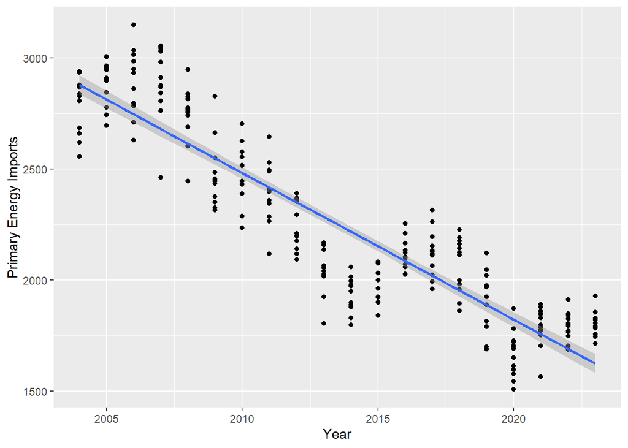

```r
#filtering the Primary Imports and Exports Data from years 2004 and onward

Extend2 <- PrimaryEnergyOverview2 %>%
  filter(Year >= 2004)

#plotting Primary Energy Imports and Exports per Year

ggplot(data = Extend2) +
  geom_point(aes(x = Year, y = `Primary Energy Imports`)) +
  geom_smooth(aes(x = Year, y = `Primary Energy Imports`), method = lm)
```

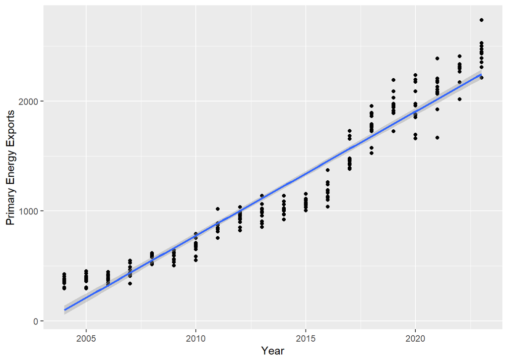

```r
ggplot(data = Extend2) +
  geom_point(aes(x = Year, y = `Primary Energy Exports`)) +
  geom_smooth(aes(x = Year, y = `Primary Energy Exports`), method=lm)
```

```r
#creating summary statistics for Primary Energy Imports and Exports

Extend2 %>% group_by(Year) %>%
  summarize(`Minimum Energy Imports` = min(`Primary Energy Imports`, na.rm = T), `Maximum Energy Imports`= max(`Primary Energy Imports`), `Mean Energy Imports` = mean(`Primary Energy Imports`, na.rm = T), `Minimum Energy Exports` = min(`Primary Energy Exports`, na.rm = T), `Maximum Energy Exports` = max(`Primary Energy Exports`, na.rm = T), `Mean Energy Exports` = mean(`Primary Energy Exports`, na.rm = T)) %>%
  ungroup() %>%
  distinct() %>%
  kbl(caption = "Summary Statistics for Primary Energy Imports and Exports", "html") %>%
  kable_material_dark()
```

Summary Statistics for Primary Energy Imports and Exports

| Year | Minimum Energy Imports | Maximum Energy Imports | Mean Energy Imports | Minimum Energy Exports | Maximum Energy Exports | Mean Energy Exports |
| --- | --- | --- | --- | --- | --- | --- |
| 2004 | 2557.755 | 2939.559 | 2791.021 | 293.786 | 425.789 | 362.6134 |
| 2005 | 2696.854 | 3008.039 | 2888.273 | 294.863 | 451.143 | 371.8238 |
| 2006 | 2630.297 | 3149.640 | 2887.399 | 328.768 | 446.167 | 393.9448 |
| 2007 | 2461.838 | 3054.552 | 2889.878 | 339.708 | 549.215 | 444.8175 |
| 2008 | 2446.439 | 2948.052 | 2747.531 | 515.312 | 617.231 | 579.0985 |
| 2009 | 2315.794 | 2827.832 | 2474.195 | 502.204 | 643.756 | 576.6834 |
| 2010 | 2236.021 | 2704.398 | 2488.814 | 551.748 | 791.941 | 681.3359 |
| 2011 | 2117.784 | 2645.132 | 2395.665 | 753.172 | 1017.562 | 864.3932 |
| 2012 | 2093.128 | 2391.594 | 2255.679 | 823.604 | 1035.291 | 938.9460 |
| 2013 | 1804.200 | 2168.373 | 2051.881 | 853.621 | 1139.164 | 982.2954 |
| 2014 | 1798.325 | 2058.377 | 1936.749 | 923.229 | 1139.668 | 1022.4814 |
| 2015 | 1839.729 | 2081.931 | 1982.806 | 1005.700 | 1155.870 | 1075.1793 |
| 2016 | 2026.277 | 2253.790 | 2114.841 | 1037.638 | 1371.734 | 1176.6006 |
| 2017 | 1959.252 | 2314.684 | 2121.488 | 1380.433 | 1726.816 | 1495.4665 |
| 2018 | 1860.679 | 2227.522 | 2069.439 | 1524.590 | 1954.641 | 1768.6379 |
| 2019 | 1688.425 | 2121.899 | 1905.436 | 1724.712 | 2190.414 | 1956.2973 |
| 2020 | 1507.487 | 1871.493 | 1665.672 | 1658.983 | 2236.072 | 1955.3270 |
| 2021 | 1565.742 | 1890.417 | 1787.949 | 1666.903 | 2386.337 | 2089.2874 |
| 2022 | 1686.566 | 1912.767 | 1792.229 | 2016.371 | 2406.805 | 2277.7078 |
| 2023 | 1714.478 | 1928.053 | 1805.417 | 2212.499 | 2736.412 | 2438.5845 |

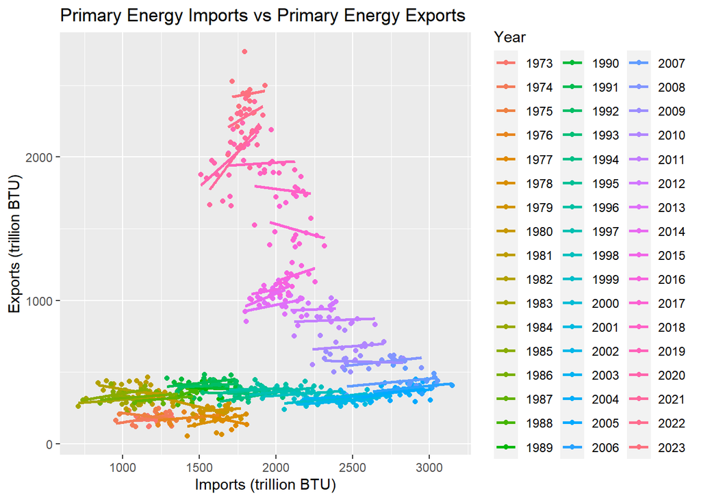

```r
ggplot(PrimaryEnergyOverview2 %>%
         mutate_at(1, as.character), #convert to character to separately analyze the data for each year
       aes(x=`Primary Energy Imports`, y=`Primary Energy Exports`, color = Year)) +
  geom_point() +
  geom_smooth(method=lm, se=FALSE) +
  labs(title = "Primary Energy Imports vs Primary Energy Exports",
       x = "Imports (trillion BTU)", y = "Exports (trillion BTU)")
```

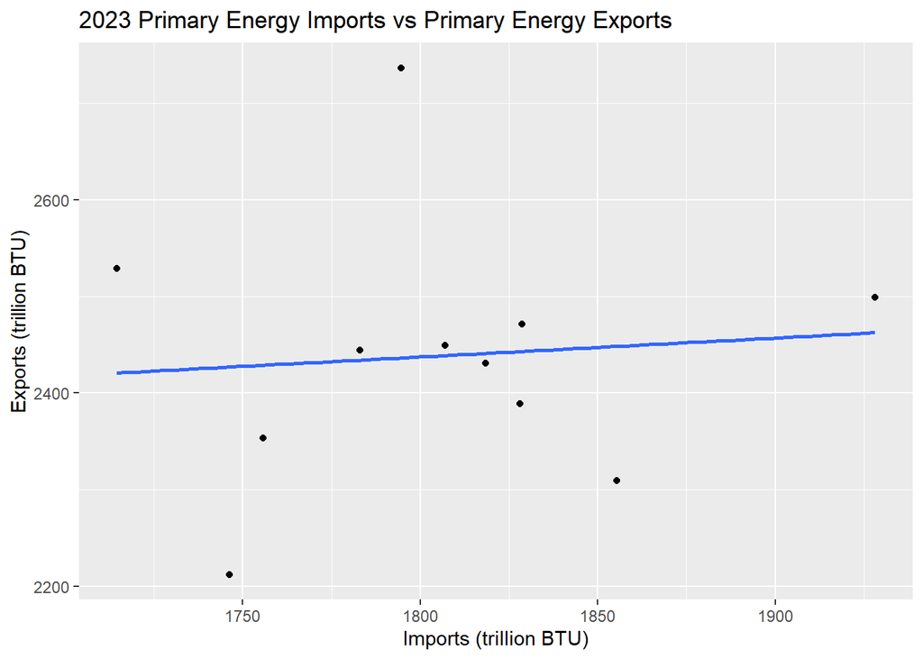

```r
PrimaryEnergyOverview2023 = PrimaryEnergyOverview2 %>%
  filter(Year == 2023)

ggplot(PrimaryEnergyOverview2023, aes(x=`Primary Energy Imports`, y=`Primary Energy Exports`)) +
  geom_point() +
  geom_smooth(method=lm, se=FALSE) +
  labs(title = "2023 Primary Energy Imports vs Primary Energy Exports",
                 x = "Imports (trillion BTU)", y = "Exports (trillion BTU)")
```

# Summary

The investigation of the data allowed us to have a visual understanding of the dataset among energy consumption and sources. Energy consumption for each sector differed in that the industrial sector accounted for the most and the commercial accounted for the least. Energy loss for each sector showed a different trend where the commercial sector had the most energy loss respective to the total consumption, while transportation barely had energy loss for its energy consumption. From exploring the contrast between nonrenewable and renewable energy production and consumption, we found that nonrenewable energy sources increased much more from 1973 to 2023 than renewable energy source consumption. However, this trend started to reverse itself at the beginning of the 2000s and onward. Renewable energy production and consumption both strongly impacted electrical loss, while nonrenewable energy production and consumption had decidedly fewer impacts in magnitude. Energy consumption by source by season showed a significant increase during the winter. This was unexpected due to the large consumption of electricity by AC. In hindsight, this made sense because natural gas is used to heat homes in the winter. In addition, the industrial sector used a lot more energy than the commercial sector every year. It led us to question what goes into maintaining each sector. Out of the total amount of energy consumption, less of it was primary consumption as the years went on until it started increasing again after 2000. We were surprised that the proportions of primary and end-use consumption differ so much between the industrial sector and the others. Initial exploration of the relationship between primary energy imports and exports showed an interesting pattern within a certain range of imports and exports. A basic scatter plot showed that between import ranges ~1500 to ~2500 and exports >1000, the data strayed from a mostly flat/neutral relationship. This observation encouraged us to find out more about these data points and the why behind them. Additionally, we were surprised to see the reflection of economic recessions in energy consumption; particularly, we saw that the commercial sector’s energy consumption had less of a change than the industrial sector during economic recessions. This essentially helped us lead to the additional questions to consider how real-world events affect energy trends.